# Introdução à Ciência dos Dados

Conforme definido no Livro [IFIP Guide to Concepts and Terms in Data Processing](https://www.amazon.com/I-F-I-P-guide-concepts-terms-processing/dp/0720420474) e apresentado em artigo da [Forbes](https://www.forbes.com/sites/gilpress/2013/05/28/a-very-short-history-of-data-science/#7089f2455cfc), dados são representações de fatos e/ou ideias de forma a serem comunicados e/ou manipulados por algum processo. E, conforme afirmado no Livro [Data Science From Scratch: First Principles with Python](https://www.amazon.com.br/Data-Science-Scratch-Principles-Python/dp/149190142X), o mundo está tendo uma verdadeira explosão na geração de dados. Sites rastreiam os cliques dos usuários, *smartphones* criam registros de localização, carros coletam hábitos de condução, governos divulgam dados a respeito dos Estados e da população e por aí vai.

Vinculado a toda esta montanha de dados aparece um termo que vem sendo bastante utilizado: **Ciência dos Dados** e o profissional chamado **Cientista dos Dados**. Pode-se dizer que estes dois termos tem a ver com o fato de que a montanha de dados citada logo acima pode trazer bastante conhecimento novo.

Diz-se que cientistas dos dados são pessoas que sabem mais estatística do que cientistas da computação e sabem mais computação do que estatísticos. Todavia, essa conversa não é tão simples e o termo cientista dos dados, junto com a área em si, a ciẽncia dos dados, não é algo fácil de definir. Um dos fatores para isso é a imprecisão com relação á abrangência do termo em si e dos profissionais que se denominam cientistas dos dados.

## A Ciência dos Dados

Uma definição ampla e interessante é apresentada no Livro [Data Science for Business: What You Need to Know about Data Mining and Data-Analytic Thinking](https://www.amazon.com.br/Data-Science-Business-Data-Analytic-Thinking/dp/1449361323): *a ciência dos dados envolve princípios, processos e técnicas para o entendimento de fenômenos através de análise de dados, seja ela automatizada ou não*. Vale notar que o termo "fenômeno" é usado desta forma genérica justamente para representar a generalidade do campo. Em outras palavras, de certa forma, a ciẽncia dos dados seria aplicável explícita e implicitamente em quase qualquer campo do conhecimento.

Várias pessoas que se interessam pelo campo de ciência dos dados e/ou estejam antenadas com as novidades da tecnologia provavelmente já ouviram falar do termo aprendizado de máquina. Diz-se que o aprendizado de máquina é a área da ciência da computação que usa estatística para prover aos computadores a capacidade de aprender com dados, mesmo sem explicitamente terem sido programados para aprender aquilo em específico. Ou seja, uma definição vinculada à palavra "dados". Vale dizer que o aprendizado de máquina e a estatísticas são campos que tem interseção com a ciência de dados (ou, a depender do ponto de vista, estão inteiramente contidos neste campo, embora sejam resultado de interseções com outros campos também).

Conforme destaca o site [Data Science Central](https://www.datasciencecentral.com/profiles/blogs/difference-between-machine-learning-data-science-ai-deep-learning), a ciência dos dados não se restringe ao aprendizado de máquina. A ciência dos dados pode vir ou não de máquinas, e/ou de processos mecânicos, como por exemplo pesquisas com pessoas. De maneira ampla, a ciência dos dados lida com:

- Integração de dados;
- Arquiteturas distribuídas;
- Aprendizado de máquina automatizado;
- Visualização de dados;
- BI (*Business Intelligence*);
- Engenharia de dados;
- DDD (*Data drive decisions*).

E a lista acima não é taxativa, há muito além. De certa forma, os interessados em vários campos podem ter ouvido falar a respeito do termo "Ciência dos Dados" de formas distintas e em contextos distintos. Vale enfatizar, todavia, que o parágrafo acima não tem a intenção de diminuir a relevância da área de aprendizado de máquina (junstamente com a sub-area aprendizado profundo). Este campo, diga-se de passagem, tem causado grande alvoroço com resultados bastante interessantes nos últimos tempos, conforme pode ser visto em artigo do site [Medium](https://medium.com/basic-income/deep-learning-is-going-to-teach-us-all-the-lesson-of-our-lives-jobs-are-for-machines-7c6442e37a49) que apresenta um texto bastante elaborado e bem fundamentado a respeito de avanços da área.

## Só agora?

Conforme afirmado no Livro [Doing Data Science](https://www.amazon.com/Doing-Data-Science-Straight-Frontline/dp/1449358659), foi nos tempos recentes passou-se a existir uma disponibilidade enorme de dados sobre inúmeros aspectos da vida das pessoas e, também, poder computacional a mão. Um termo que surge em decorrência disso é o chamado *datafication*, que não tem uma tradução muito interessante para a língua portuguesa, mas que relaciona-se à quantiicação de ações, muitas vezes providas de forma voluntária pelas pessoas. O exemplo citado no livro em questão é a quantifiação do grau de proximidade que pessoas têm a partir do botão "curtir" do Facebook.

A partir do parágrafo anterior, o leitor pode ser induzido a concluir que o campo em si em novo. Embora certas vertentes venham sendo exploradas apenas recentemente, e os desafios junto com estas explorações, o campo não teve teve início apenas recentemente com empresas tais quais Google, Facebook, IBM, dentre outros gigantes da tecnologia. A pessoa pode ser induzida a pensar nisso em decorrência, também, do interesse apenas recente da mídia por relatar este assunto ao público leigo. Vale destacar os dois pontos:

- Há de se respeitar e valorizar o longo trabalho feito por matemáticos, estatísticos e cientistas da computação para elaborar as bases nas quais recaem as várias técnicas utilizadas recentemente;
- É interessante considerar, ao mesmo tempo, que a grande atenção que estes campos vem recebendo, e o decorrente avanço da área, tem feito dos tempos recentes um dos mais prósperos nesta direção.

Para os interessados em alguns avanços históricos na área, o artigo da [Forbes, A Very Short History Of Data Science](https://www.forbes.com/sites/gilpress/2013/05/28/a-very-short-history-of-data-science/#7089f2455cfc), traz alguns fatos interessantes relacionados à area de ciência dos dados.

## A importância da análise de dados

O Livro [Data Science for Business: What You Need to Know about Data Mining and Data-Analytic Thinking](https://www.amazon.com.br/Data-Science-Business-Data-Analytic-Thinking/dp/1449361323) traz alguns exemplos interessantes a respeito da criticidade e importância de análise de dados. Um dos exemplos fala a respeito do Furacão Frances, com uma publicação feita pelo jornal *New York Times* em 2004. O trecho de texto em questão citava a evacuação das áreas que foram atingidas pelo furacão baseadas em predições feitas nas quantidades enormes de dados recolhidas várias semanas antes, a partir de dados de um evento anterior, o Furacão Charley.

É possível trazer um exemplo também no contexto do mercado. O blog do [Walmart](https://blog.walmart.com/innovation/20170807/5-ways-walmart-uses-big-data-to-help-customers) publicou em certa ocasião uma ilustração mostrando como o Walmart usa os dados para aprimorar seus serviços. A empresa argumenta no artigo sobre a importância dos dados, e alguns exemplos de uso destes dados são destacados abaixo:

- São feitas simulações nas farmácias para encontrar os números de prescrições preenchidas no dia para determinar os horários de pico durante o dia ou no mês;
- A empresa usa análises preditivas para antecipar demandas em certos horários para determinar quantas pessoas ficam nos caixas. Ao analisar os dados a empresa tenta identificar as melhores formas de registrar as compras;
- Simulaçõs são utilizadas para verficar o número de passos desde os estaleiros à loja. Estes tipos de informações podem ser utilizadas para otimizar rotas de transportação, diminuindo os custos e o tempo de transporte;
- Através das análises de preferência dos consumidores e padrões de compreas, a companhia acelara o processo de decisão organização dos produtos na loja;

## O profissional: Cientista de Dados

Na academia, não há o hábito das pessoas se identificarem como Cientista de Dados, exceto de maneira secundária para o fim de estar em algum "Instituto de Ciência de Dados", conforme explicitado no livro [Doing Data Science](https://www.amazon.com/Doing-Data-Science-Straight-Frontline/dp/1449358659). Há, ainda, uma tendência dos acadêmicos a não irem atuar no campo por conta da falta de formalização da área de estudo em si, com sua correta delimitação. Conforme o livro explicita, um cientista de dados acadêmico é alguém, variando das ciências sociais à biologia, que trabalha com grandes quantidades de dados.

Já no mercado / industria, o cientista de dados tem um papel bastante versátil e sequer precisa estar vinculado à area de tecnologia. Por exemplo, um cientista de dados gestor poderia estar analisando dados para traçar estratégias da empresa, fundamentar decisões, etc. O profissional, no geral, passa bastante tempo processando os dados, que quase nunca vêm "limpos". Uma vez que os dados estejam na forma desejada, entra em cena a análise exploratória dos dados. Nesse passo descobrem-se padrões, modelos e algoritmos para tratar casos específicos.

Em geral, há um conjunto geral de habilidades interessantes para quem quer atuar com análise de dados no mercado. O blog da [Udacity](https://blog.udacity.com/2014/11/data-science-job-skills.html) apresentou um artigo mostrando vários destes *skills*, alguns deles relatados abaixo:

- **Programação**: provavelmente será necessário ter alguma noção de linguagens como Python ou R, por exemplo, e algumas bases de dados;
- **Estatística**: é interessante saber a respeito de testes estatísticos, distribuições, medidas de tendência central, etc.;
- **Aprendizado de Máquina**: em companhias com grandes quantidades de dados, isso provavelmente será de bastante relevância, conforme pôde ser visto no exemplo anterior do Walmart;
- **Cálculo Infinitesimal e Álgebra Linear**: importante especialmente em cenários onde pequenas otimizações em heurísticas aplicadas aos produtos possam dar grandes ganhos em qualidade ou outra característica;
- **Imputação de Dados**: os dados comumente não virão de maneira "limpa" e pronta. Saber lidar com dados faltantes e inconsistências é essencial;
- **Visualização de Dados**: buscar formas interessantes de visualizar os dados é bastante importante para ajudar as pessoas a entendê-los.

# Python 3

Python foi criado no final dos anos 80 por Guido van Rossum.

[figure not shown]

Fonte: [Wikipedia](https://en.wikipedia.org/wiki/Guido_van_Rossum)

Python3 se trata de uma versão mais atualizada lançada em 2008 com o intuito de consertar erros de design que existiam nas versões anteriores.

Não importando a versão que se esta usando, códigos em python devem recair no Zen of Python ou a Filosofia de Python, que resumidamente significa manter a simplicidade e a legibilidade. Para os interessados, o conjunto de regras se encontra na página [Python Philosophy](http://wiki.c2.com/?PythonPhilosophy), da [WikiWikiWeb](http://wiki.c2.com/).

# Porquê Python?

Desde seu surgimento Python tornou-se uma das linguagens interpretadas mais populares. Devido a sua natureza simples, pode-se criar tarefas automatizadas com poucas linhas de código. Todavia, constitui uma linguagem muito poderosa não somente para tarefas pequenas. Nas últimas décadas a linguagem recebeu amplo suporte da comunidade ciêntífica, resultando em diversos módulos com grande desempenho para tratamento de dados, podendo ser comparada a outras ferramentas como R ou MATLAB.

Em muitas empresas é comum fazer protótipos em outras linguagens, como por exemplo C++ ou Java. Entretanto, para boa parte dos problemas de análise, o tempo gasto para fazer a solução funcionar se mostra menos importante que o tempo necessário para solucionar o problema. O Python pode ser utilizado tanto na prototipação quanto na solução final com desepenho satisfatório. Logo, resolve o problema da necessidade de mais de uma ferramenta.

# O poder da linguagem

Para demonstrar o poder dessa linguagem, será apresentado um exemplo razoavelmente complexo, feito por meio de python e suas bibliotecas. Este exemplo consta no artigo [Visualization: Mapping Global Earthquake Activity, do blog Introduction to Python](http://introtopython.org/visualization_earthquakes.html). Para maiores detalhes, recomenda-se a leitura da referência. Vale ressaltar que o blog inclui explicações sobre a linguagem Python e mostra-se bastante interessante. Os assuntos lá abordagos também serão apresentados aqui.

## Banco de dados de terremotos

O Governo dos Estados Unidos provê em tempo real dados sobre todos os terremotos que ocorrem. É possível baixar dados da última hora até os últimos 30 dias. Para este exemplo são utilizados os eventos dos últimos 7 dias, os quais possuíram magnitude maior que 1.0. No site do [USGS - Earthquake Hazards Program](https://earthquake.usgs.gov/earthquakes/feed/v1.0/csv.php) é possível fazer o download dos dados. O arquivo utilizado é o ["Past 7 Days M1.0+ Earthquakes"](https://earthquake.usgs.gov/earthquakes/feed/v1.0/summary/1.0_week.csv).

## Antes de continuar...

Digite `anaconda prompt` no iniciar do Windows para abrir um novo terminal, nele digite `conda install -c conda-forge basemap` para ter acesso a uma biblioteca do mapa mundi para executar o exemplo abaixo.

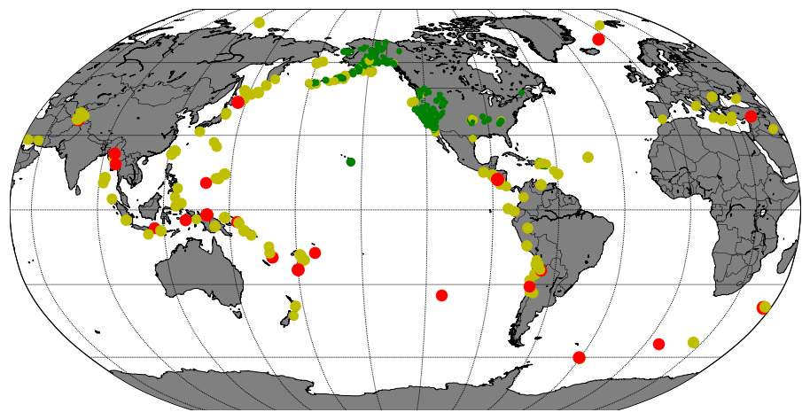

```python
import pandas as pd
import matplotlib.pyplot as plt
import numpy as np
import warnings; warnings.simplefilter('ignore')
% matplotlib inline
arquivo = "databases/1.0_week.csv" # 23/04 a 30/04

lat = []
long = []
magnitude = []

df = pd.read_csv(arquivo)

lat = df['latitude'].tolist()
long = df['longitude'].tolist()
magnitude = df['mag'].tolist()

from mpl_toolkits.basemap import Basemap

plt.figure(figsize=(16,12))
mapa = Basemap(projection="robin", resolution = "l", area_thresh = 1000.0, lat_0=0,lon_0=-130)
mapa.drawcoastlines()
mapa.drawcountries()
mapa.fillcontinents(color='gray')
mapa.drawmapboundary()
mapa.drawmeridians(np.arange(0,360,30))
mapa.drawparallels(np.arange(-90,90,30))

menor_marcador = 2.5
for ln, lt, mag in zip(long, lat, magnitude):
    x,y = mapa(ln, lt)
    marker = mag*menor_marcador
    color = 'go' if mag < 3.0 else 'yo' if mag < 5.0 else 'ro'
    mapa.plot(x,y,color,markersize=marker)
plt.show()
```

# Meios de interação com a linguagem

Por padrão ao instalar o python uma IDE (Integrated Development Environment) chamada IDLE vem junto, porém ela se mostra muito simples, e acaba dificultando o aprendizado. Segue um exemplo do IDLE:

[figure not shown]

Outras soluções existem no mercado e na comunidade para tornar mais prazeroso o estudo. Pode-se citar, por exemplo, IDEs (*Integrated Development Environment*) como pyCharm, Spyder, Visual Studio Code entre outras, e até a aplicação Web Jupyter Notebook (utilizada neste curso), que muito auxiliam na fluidez do aprendizado. Segue um exemplo de interface do Visual Studio Code:

[figure not shown]

# Introdução ao Jupyter Notebook

Caso tenha seguido o tutorial de configuração para este curso, o Jupyter já estará instalado em sua máquina por meio da distribuição Anaconda do Python. O Jupyter Notebook se baseia em uma estrutura de células para organizar os seus dados. Possui também uma metodologia exploratória da codificação da solução, o que proporciona uma maior interação com o código e, em geral, maior facilidade para resolver problemas.

Para melhor situar o leitor recomenda-se como leitura adicional o livro "Learning Jupyter", por Dan Toomey: https://www.packtpub.com/big-data-and-business-intelligence/learning-jupyter

## Células

Célula é uma área editável que pode ser *Markdown*, Código, Área de Títulos, ou Texto sem Formatação. Para este curso, iremos focar em apenas os dois tipos principais: *Markdown*, para a edição de textos, e Código, para o desenvolvimento das apilcações onde iremos utilizar o Python3.

## *Markdown*

*Markdown* é uma linguagem simples de marcação, utilizada para edição de textos.

Uma palavra ou frase pode ser destacada colocando *underlines* entre as mesmas da seguinte forma: `_underline_`.

De maneira similar, utilizam-se dois *underlines* nos extremos de uma palavra ou frase, para que a mesma apareça em **negrito**: `__negrito__`.

Para código, coloca-se os termos entre acentos grave (`). Exemplo: `codigo`.

Para criar listas, utiliza-se asterisco ou um número precedido de um ponto. Exemplos

1. Item 01

2. Item 02

(espaço)(espaço)(espaço)* Item 03

(espaço)(espaço)(espaço)* Item 04

Irá resultar em:

1. Item 01
2. Item 02
   - Item 03
   - Item 04

Citações podem ser feitos utilizando o símbolo `>` antes do início da frase:

> Exemplo de Citação

Links são inserindo utilizando a seguinte sintaxe: `[Texto do link](link do link)`

Exemplo: [Pudim](http://www.pudim.com.br)

A inserção de imagens possui uma sintaxe similar a de links, com a diferença em que deve-se acrescentar um sinal de exclamação no início da frase(`![Título da imagem](caminho ou URL para a imagem)`). Segue um exemplo:

[figure not shown]

- Inserção local: `![Python](images/1_python-logo.png)`
- Inserção por URL: `![Python](https://www.python.org/static/img/python-logo.png)`

## Código Python3

Na célula abaixo teremos um exemplo de uma célula em modo código, que possibilita executar scripts python de maneira interativa, ou seja, pode-se obter os resultados célula a célula, vendo o que acontece aos poucos. Ao lado esquerdo há um `In[ ]`, o que denota que a célula ainda não foi executada, `In[*]` que esta e execução, e `In[número]` a ordem de execução. O comando abaixo utiliza a função `print` que exibe o que for passado como conteúdo ('olá mundo') para a saída da execução (tela). Para executar o código abaixo, selecione, e utilize o comando `Ctrl+Enter`.

```python
print("olá mundo")
```

```
olá mundo
```

Provavelmente, a demarcação da célula foi para `In[2]`, indicando que esta é a segunda célula de código a ter sido executada nestas notas. Esta é uma informação importante, porque células com números maiores indicam que foram executados depois (são mais recentes), e como o Jupyter trabalha de forma interativa, células podem usar informações umas das outras, e o conteúdo executado fica guardado na memória até que uma execução mais recente o substitua.

## Comandos do Jupyter

Alguns comandos podem ser úteis ao utilizar jupyter para aumentar a sua produtividade, alguns dos principais são:

| Atalho | Função |
| --- | --- |
| Enter | Entra no modo de edição de célula |
| Ctrl+Enter | Executa a célula |
| Y | Marca a célula como código |
| M | Marca a célula como markdown |
| A | Cria uma nova célula acima da atual |
| B | Cria uma nova célula abaixo da atual |

### Comandos modo código

| Atalho | Função |
| --- | --- |
| Tab | Auto-Completar do código ou identar |
| Ctrl+Z | Voltar |
| Ctrl+Y | Refazer |
| Esc | Entra no modo de comandos do Jupyter |
| Ctrl+Enter | Executa a célula |

Mais comandos e atalhos podem ser encontrados no [Guia de Atalhos do Jupyter](https://www.cheatography.com/weidadeyue/cheat-sheets/jupyter-notebook/).

# Introdução ao Python 3

Python é uma linguagem de programação de **alto nível** (mais próximo da linguagem humana), **interpretada** (execução é enviada para o Sistema Operacional linha-a-linha por um interpretador), de **script** (automatização de tarefas), **imperativa** (computação como ações que modificam o estado), **orientada a objetos** (paradigma de programação baseado no conceito de objetos), **funcional** (paradigma de programação que trata computação como avaliação de função), de **tipagem dinâmica** (tipos não são explicitamente definitos) e **forte** (atribuições só podem ser feita para o mesmo tipo).

## Tipos de dados

Dados podem ser divididos em primitivos e customizados, sendos os primitivos os já existentes na linguagem, em geral encontrados em todas as linguagens de programação. Já os customizados constituem os tipos criados pelo programador para auxiliar o desenvolvimento da aplicação.

| Tipo | Construtor |
| --- | --- |
| Inteiro | int() |
| Real | float() |
| String | str() |
| Booleano | bool() |

```python
print(1)
print(type(1))
```

```
1
<class 'int'>
```

```python
print(3.5)
print(type(3.5))
```

```
3.5
<class 'float'>
```

```python
print('Cadeia de Caracteres')
print(type('Cadeia de Caracteres'))
```

```
Cadeia de Caracteres
<class 'str'>
```

```python
print(True)
print(type(True))
```

```
True
<class 'bool'>
```

Repare que a cada teste, o conteúdo a ser exibido, seja o número ou outro conteúdo, foi escrito duas vezes, isto pode facilmente ser evitado por meio do uso de **Variáveis**, explicado a seguir.

## Variáveis

Uma das características mais importantes da maioria das linguagens de programação, reside na possibilidade do uso de variáveis. **Variável** é um objeto que representa um valor ou uma expressão. Ela serve para reter alguma informação em memória que poderá sofrer modificações ao longo da execução do programa.

Para criar uma variávei, utiliza-se o **comando de atribuição**, que coloca o conteúdo do tipo de dado que você criou na variável com o nome escolhido. Exemplos:

Em python não há a necessidade de declarar o tipo da variável, pois possui checagem de tipos de maneira dinâmica, assim pode-se criar uma variável sem a necessidade de declarar o seu tipo.

```python
a = 1
b = 42
s = 'Eu sou uma cadeia de caracteres'
f = True
```

Assim, é possível preservar um determinado conteúdo ou manipulá-lo durante toda a execução de um programa.

```python
carro = 'DeLorean'
print(carro)
print(type(carro))
print('A variável contém', carro, 'e é do tipo', type(carro))
```

```
DeLorean
<class 'str'>
A variável contém DeLorean e é do tipo <class 'str'>
```

Repare que a variável criada recebeu o nome de `carro` e foi utilizada diversas vezes. Primeiro no comando `print` de seu conteúdo, depois na impressão do tipo, e por último combinada para forma uma frase utilizando o conteúdo e o tipo com outras duas cadeias de caracteres.

Para facilitar a programação, é comum utillizar nomes que sejam intuitivos ao entendimento do programa. Esses nomes podem conter letras, números e o caractere `_`, porém não pode ser iniciadas por números. São exemplos válidos de variáveis `a, _tempo_, diaDoMes, dia_do_mes, valor7`. Letras maiúsculas e minúsculas são diferentes, então `carro`, e `Carro` são consideradas variáveis diferentes pelo interpretador do python.

```python
diaDoMes = 7
carro = 'Uno'
Carro = 'Civic'
print(carro)
```

```
Uno
```

```python
1tamanho = 4 # Erro de sintaxe - Iniciando com número
```

```
  File "<ipython-input-10-8fe99cb3329b>", line 1
    1tamanho = 4 # Erro de sintaxe - Iniciando com número
           ^
SyntaxError: invalid syntax
```

Além das regras já citadas, o Python também possui 29 palavras reservadas para outras funcionalidade da linguagem que não podem ser utilizadas como nomes de variáveis. Segue a lista de palavras reservadas:

```
and       def       exec      if        not       return
assert    del       finally   import    or        try
break     elif      for       in        pass      while
class     else      from      is        print     yield
continue  except    global    lambda    raise
```

Por último, variáveis de tipos diferentes podem ser utilizadas em conjunto no mesmo comando `print`.

```python
a = 2
b = 5.5
c = "Olá pessoas"
d = False
print(a, b, c, d) #Note que pode-se mostrar todos os valores de uma só vez
```

```
2 5.5 Olá pessoas False
```

## Entrada e saída de dados

Ao desenvolver um programa, muitas vezes é necessário interagir com o usuário de alguma forma, seja para demandar por algum dado ou informação, seja para exibir resultados dos cálculos efetuados. Para essas operações, existem as funções de entrada e saída do Python. Para exibição na tela (saída de dados), utiliza-se normalmente a função `print`.

```python
print('Mostra alguma coisa na tela')
```

```
Mostra alguma coisa na tela
```

No caso do Jupyter o Python utilizado é o IPython (Interactive Python), aqui para mostrar na tela não é necessário o `print()`, pode-se utilizar apenas o nome da variavel ou a cadeia de caractéres, porém caso necessite mostrar mais de uma saída por célula exige-se o uso do `print()`.

```python
'Mostra alguma coisa na tela.' # Não será exibido, porque não é o último conteúdo da célula
'Mostra outra coisa na tela.'
```

```
'Mostra outra coisa na tela.'
```

É possível inserir variáveis na saída de um `print` de duas forma:

- utilizando `{}` para definir onde será colocada cada variável

```python
nome = 'John'
idade = 29
print("{} tem {} ano(s) e R${} reais.".format(nome, idade, 199.13))
```

```
John tem 29 ano(s) e R$199.13 reais.
```

- colocando os conteúdos do `print` entre vírgulas

```python
nome = 'John'
idade = 29
print(nome, "tem", idade, "ano(s) e R$199.13 reais.")
```

```
John tem 29 ano(s) e R$199.13 reais.
```

Já a entrada de dados é realizada pela função `input`. A função `input` recebe do usuário uma entrada de dados até que a tecla `Enter` seja pressionada.

```python
print("O valor atual de a = {}".format(a))
a = input()
print("O valor de a agora = {}".format(a))
```

```
O valor atual de a = 2
5
O valor de a agora = 5
```

### Exercícios

#### Questão 1

Faça um programa que leia dois números inteiros, `a` e `b`, troque o conteúdo desses números e mostre os novos valores.

```python
# Insira o código abaixo
```

#### Questão 2

Crie um programa que leia 4 números reais, calcule e mostre a média aritmética entre eles.

```python
# Insira o código abaixo
```

#### Questão 3

Faça um programa que calcule o volume $V$ de um cilindro, dados o raio e altura do mesmo. (Obs.: $V = \pi*r^2*h $, adote $\pi = 3.14$)

```python
# Insira o código abaixo
```

#### Questão 4

Escreva um programa que receba três variáveis, `a, b` e `c`, de uma equação do segundo grau, y = ax^2 + bx + c e mostre o valor das raízes. Assumir que o discriminante (delta) sempre será maior ou igual a zero.

Teste para o seguinte conjunto de valores:

- `a = 1, b = -8, c = 15. x1 = 5, x2 = 3`
- `a = 1, b = -8, c = 0. x1 = 8, x2 = 0`
- `a = 2, b = -6, c = 4. x1 = 2, x2 = 1`
- `a = 4, b = 8, c = 3. x1 = -0.5, x2 = -1.5`

```python
# Insira o código abaixo
```

#### Questão 5

Crie um programa para mostrar a hipotenusa de um triângulo retângulo dados os valores dos catetos. Calcula-se a hipotenusa como a raiz quadrada da soma dos quadrados dos catetos.

Teste para o seguinte conjunto de valores:

- `c1 = 3, c2 = 4. h = 5`
- `c1 = 12, c2 = 9. h = 15`

```python
# Insira o código abaixo
```

#### Questão 6

Faça um programa que receba três notas e os três respectivos pesos da prova de um aluno. De pesse dessas informações, calcule e mostre a média ponderada deste aluno.

```python
# Insira o código abaixo
```

## Estruturas de Controle

Para aumentar o dinamismo dos programas que são criados, existem as **estruturas de controle**, que se baseiam em condições para determinar qual o próximo trecho de código deverá ser executado. Estas estruturas se subdividem em dois tipos: Condicionais e Repetição

### Estruturas Condicionais

Funcionam como um questionamento *se*/*senão* da língua portuguesa. Por exemplo, *"Se um número `a` for maior que `b` multiplique a por 2, senão multiplique `b` por 2"*. Essa expressão citada, pode ser traduzida diretamente para código da seguinte forma:

```python
a = 3
b = 5
if (a > b):
    a = a * 2
else:
    b = b * 2
print(a, b)
```

```
3 10
```

```python
a = 6
b = 2
if (a > b):
    a = a*2
else:
    b = b*2

print(a, b)
```

```
12 2
```

Essas estruturas podem possuir condições adicionais, por exemplo, se `a > b`, divida `a` por 2, se `a == b` some 1 às duas variaveis, senão divida `b` por 2.

```python
a = 6
b = 2

# a maior que b
if(a > b):
    a = a / 2
elif(a == b):
    a = a + 1
    b = b + 1
else:
    b = b / 2
print(a, b)
```

```
3.0 2
```

```python
a = 5
b = 5

# a igual b
if(a > b):
    a = a / 2
elif(a == b):
    a = a + 1
    b = b + 1
else:
    b = b / 2
print(a, b)
```

```
6 6
```

```python
a = 4
b = 8

# b maior que a
if(a > b):
    a = a / 2
elif(a == b):
    a = a + 1
    b = b + 1
else:
    b = b / 2
print(a, b)
```

```
4 4.0
```

Note que em todos os condicionais apresentdos, as condições de todas as estruturas foram respondidas como **Verdadeiro (*True*)** ou **Falso (*False*)**, pois estas são condições de álgebra booleana utilizadas para verificar por qual caminho o algoritmo deve seguir. Assim, de maneira adicional, essas condições podem ser combinadas em comparações mais complexas, por exemplo, combinando operações como **E (*and*)** ou **OU (*or*)**. Segue o funcionamento dessas duas operações em cláusulas:

| `p` | `q` | `p E q` |  | `p` | `q` | `p OU q` |
| --- | --- | --- | --- | --- | --- | --- |
| F | F | F |  | F | F | F |
| F | V | F |  | F | V | V |
| V | F | F |  | V | F | V |
| V | V | V |  | V | V | V |

Por exemplo, se `a` precisar ser maior que `b` `E` maior que `5` faça com que `a` seja 5, senão se `a` maior que `b` faça com que `a` receba o valor `b`:

```python
a = 6
b = 3
# a maior que b e maior que 5
if (a > b and a > 5):
    a = 5
elif (a > b):
    a = b
print(a, b)
```

```
5 3
```

```python
# a maior que b
a = 3
b = 2
if (a > b and a > 5):
    a = 5
elif (a > b):
    a = b
print(a, b)
```

```
2 2
```

```python
# a menor que b
a = 3
b = 5
if (a > b and a > 5):
    a = 5
elif (a > b):
    a = b
print(a, b)
```

```
3 5
```

As estruturas condicionais podem também ser encadeadas numa mesma linha.

```python
b = 3
# a recebe 2 se b for maior que 3, senão a recebe 1
a = 2 if b > 3 else 1
print(a)
```

```
1
```

```python
b = 4
# a recebe 2 se b for maior que 3, senão a recebe 1
a = 2 if b > 3 else 1
print(a)
```

```
2
```

### Exercícios

#### Questão 1

Faça um programa que receba um número inteiro e verifique se esse número é par ou ímpar. Obs.: Para decidir se um número é divisível por outro basta checar o resto da divisão por 2 é igual a 0. Para obter o resto de uma divisão, utiliza-se o operador `%`. Por exemplo, `5 % 2` irá resultar em `1`.

```python
# Insira o código abaixo
```

#### Questão 2

Faça programa que receba dois números inteiros e exiba menor e em seguida o maior entre eles.

```python
# Insira o código abaixo
```

#### Questão 3

Faça um algoritmo que receba três números inteiros diferentes e mostre-os em ordem decrescente.

```python
# Insira o código abaixo
```

#### Questão 4

Faça um algoritmo que leia a data de nascimento de uma pessoa, dia, mês e ano, verifique se a data pode existir e imprima a mensagem `Data válida` se a data for uma data válida ou `Data inválida` se os valores informados não formarem uma data válida. Obs.: Desconsidere anos bissextos, então fevereiro sempre terá 28 dias.

```python
# Insira o código abaixo
```

#### Questão 5

Escreva um programa que leia três coeficientes, `a, b` e `c`, de uma equação do segundo grau, $y = ax^2 + bx + c$ e mostre o valor das raízes. Se o discriminante ($\Delta$) for menor que zero imprima uma mensagem que não existem raízes reais. Obs.: $\Delta = b^2 - 4ac$ e o valor das raízes é calculado como $x = \frac{-b \pm \sqrt{\Delta}}{2a}$

Teste para o seguinte conjunto de valores:

- a = 1, b = -8, c = 15. x1 = 5, x2 = 3
- a = 1, b = -8, c = 0. x1 = 8, x2 = 0
- a = 2, b = -6, c = 4. x1 = 2, x2 = 1
- a = 4, b = 8, c = 3. x1 = -0.5, x2 = -1.5
- a = 4, b = 2, c = 1. Não existem raízes reais.

```python
# Insira o código abaixo
```

### Estruturas de Repetição

De forma semelhante as estruturas condicionais estas também necessitam de uma condição, porém ao invés de ramificar o código decidindo qual trecho será executado as estrutura de repetição, como o nome já diz, repetem o trecho se a condição for verdadeira.

Pode ser pensada de duas maneiras quando se traduz para português, a primeira sendo:

"*Enquanto ocorre uma condição repita este trecho.*"

```python
# Calcular a potencia de 2
n = int(input())
indice = 1
resultado = 1
while (indice <= n):
    resultado = resultado * 2
    indice = indice + 1
print(resultado)
```

```
3
8
```

E a segunda de maneira contada:

De 1 até 10 repita este trecho

```python
# Somar todos os numeros de 1 a 10
soma = 0
for i in range(1, 11): # A função range() percorre elementos do primeiro até o penúltimo valor (ou seja, 11 - 1)
    soma = soma + i
print(soma)
```

```
55
```

Essas estruturas também podem ser aninhadas para para gerar repetições mais complexas, como por exemplo a combinação de dois intervalos de valores. Como exemplo, vamos apresentar a soma de todos os pares de valores de 1 a 3:

```python
for i in range(1, 4):
    for j in range(1, 4): # Repare que este laço é executado
        print(i, '+', j, '=', i + j)
```

```
1 + 1 = 2
1 + 2 = 3
1 + 3 = 4
2 + 1 = 3
2 + 2 = 4
2 + 3 = 5
3 + 1 = 4
3 + 2 = 5
3 + 3 = 6
```

### Exercícios

#### Questão 1

A conversão de graus Fahrenheit para Celsius é obtida por $c = \frac{5}{9}*(f-32)$. Faça um algoritmo que calcule e escreva uma tabela de graus F para C cujos graus variem de 0 a 50, de 1 em 1.

```python
# Insira o código abaixo
```

#### Questão 2

Faça um algoritimo que apresente a soma acumulada dos valores de 1 a 100.

```python
# Insira o código abaixo
```

#### Questão 3

Faça um algoritmo que receba dez números, representando a nota de dez alunos, obtenha:

- Soma das notas
- Média das notas

```python
# Insira o código abaixo
```

#### Questão 4

Faça um algoritmo que receba um valor do usuário exiba a tabuada desses números múltiplicados de 0 a 10.

```python
# Insira o código abaixo
```

#### Questão 5

Um funcionário de uma empresa recebe aumento salarial anualmente. Sabe-se que:

- Contratado em 1992, com salário de R$1000
- Em 1993 recebeu aumento de 1,2%
- Em 1994 recebeu aumento de 1,8%
- A partir de 1995 (inclusive), os aumentos sempre corresponderam ao último aumento mais 0.7%.

Calcule o salário deste funcionário em 2018.

```python
# Insira o código abaixo
```

#### Questão 6

Faça um algoritmo que mostre todos os números pares entre 25 e 100.

```python
# Insira o código abaixo
```

#### Questão 7

Mostre o valor de `n!` (fatorial) Teste para os seguintes valores:

- n = 0, r = 1
- n = 1, r = 1
- n = 2, r = 2
- n = 3, r = 6
- n = 4, r = 24
- n = 5, r = 120

```python
# Insira o código abaixo
```

## Estruturas de dados

Para aumentar a produtividade, Python conta com algumas estruturas incorporadas a linguagem, sendo as principais listas e dicionários.

### Listas

Como o nome implica, serve para criar listas que possibilitam guardar mais de um dado em uma mesma variável.

```python
lista = [] # Cria uma lista vazia
print(lista)
lista.append(7) # Adiciona um elemento a lista
lista.append(10)
print(lista)
lista.remove(7) # Remove o valor 7 da lista
print(lista)
lista.append(10)
lista.append(2)
print(lista)
```

```
[]
[7, 10]
[10]
[10, 10, 2]
```

Elementos de uma lista podem ser acessados a partir de seus índices (posições na lista). Esses **índices iniciam do elemento 0**, e não do 1. Assim, no índice 0 está o primeiro elemento, portanto o último elemento de uma lista corresponde ao tamanho da lista menos uma unidade. A função `len()` pode ser utilizada para verificar o tamanho de uma lista.

```python
lista = [4, 3, 2, 6, 11, 12, 16, 7, 8, 9]
tamanhoLista = len(lista)
print('Tamanho da lista: {}'.format(tamanhoLista))
print(lista[0])
print(lista[1])
print(lista[4])
print(lista[tamanhoLista - 1])
```

```
Tamanho da lista: 10
4
3
11
9
```

#### Slicing (Fatiamento)

Pode-se cortar as listas em partes, caso queira trabalhar apenas com parte dessa estrutura.

```python
listaPares = [2, 4, 6, 8, 10, 12, 14, 16, 18, 20]

print(listaPares)
print(listaPares[:4])  # Lista até o quarto elemento
print(listaPares[5:])  # Lista depois do quinto elemento (salta o quinto)
print(listaPares[4:8]) # Lista depois do quarto até o oitavo elemento
```

```
[2, 4, 6, 8, 10, 12, 14, 16, 18, 20]
[2, 4, 6, 8]
[12, 14, 16, 18, 20]
[10, 12, 14, 16]
```

### Pertinência de listas

Pode-se checar se um determinado elemento pertence a uma lista através do operador `in`, que retornará `True`, se o elemento pertencer a lista, e `False`, caso contrário. Além disso, é possível combinar com o operador `not` para verificar se um determinado elemento não pertence àquela lista.

```python
lista = [0, 2, 4, 6, 8, 10, 12]

print(2 in lista)         # Pertence a lista?
print(2 in lista[:5])     # Pertence a sub-lista até o quinto elemento?
print(2 in lista[5:])     # Pertence a sub-lista depois do quinto elemento?
print(2 not in lista[5:]) # Não pertence a sub-lista depois do quinto elemento
```

```
True
True
False
True
```

A partir do conhecimento de que um determinado valor encontra-se em na lista, pode recuperar o índice referente aquele valor utilizando o método `index`.

```python
valores = [100, 200, 250, 111, 400]

if 111 in valores:
    posicao = valores.index(111)
    print('111 está na posição', posicao)
```

```
111 está na posição 3
```

#### Remoção de item

Além do método `remove`, apresentado anteriormente, existem outras formas de se remover itens de uma lista, como, por exemplo o método `pop(<indice>)`. `pop(<indice>)` é normalmente mais utilizado, porque o método `remove(<conteudo>)` retira o primeiro elemento da lista que possua o conteúdo especificado, podendo gerar confusões em listas que contenham elementos repetidos.

```python
lista = [3, 4, 5, 6, 7, 8, 9, 10, 11, 5, 13]

print(lista)
lista.pop(5) # Remove o sexto elemento, lembre-se que a lista começa em 0, logo 5 será o sexto elemento
print('Primeira remoção (8):', lista) #Lista sem o sexto elemento
lista.remove(5) # Retira da lista elemento que tenha o conteudo 5 dentro dele
print('Segunda remoção (primeira ocorrência do 5):', lista)

lista.pop(5) # Quem será removido???
print()
```

```
[3, 4, 5, 6, 7, 8, 9, 10, 11, 5, 13]
Primeira remoção (8): [3, 4, 5, 6, 7, 9, 10, 11, 5, 13]
Segunda remoção (primeira ocorrência do 5): [3, 4, 6, 7, 9, 10, 11, 5, 13]
```

#### Compreensão de listas

Listas podem ser utilizadas junto de estruturas de repetição. Ao invés de passar um conjunto de números sobre os quais o índice será iterado (exemplo: `range(1, 11)`, pode-se passar uma lista e assim o índice se tornará um elemento da lista, por exemplo:

```python
lista_nomes = ["Joao", "Maria", "Jose", "Alice", "Bob"]
for nome in lista_nomes: # Para cada nome dentro de lista_nomes faça
    print('Nome:', nome) # Mostre o nome atual
```

```
Nome: Joao
Nome: Maria
Nome: Jose
Nome: Alice
Nome: Bob
```

Além de usar as estruturas de repetição contadas para acessar os elementos da lista um-a-um, pode-se utilizá-las para criar novas listas seguindo estruturas condicionais. Dessa forma, pode-se mesclar ambas estruturas com listas. Abaixo, segue um exemplo de código utilizando compreensão de listas e um exemplo que sem a utilizar para ilustrar melhoria e aumento de produtividade.

```python
# Objetivo: Adicionar a uma lista todos os números múltiplos de 7 entre 1 a 100

# Maneira convencional
numeros = []
for i in range(1, 101):
    if(i % 7 == 0):         # O operador % (mod) devolve o resto da divisão de i por 7
        numeros.append(i)   # se o resto for 0 significa que o número é divisivel por 7
print(numeros)

# Utilizando compreensão de listas
numeros = [i for i in range(1, 101) if i % 7 == 0]
print(numeros)
```

```
[7, 14, 21, 28, 35, 42, 49, 56, 63, 70, 77, 84, 91, 98]
[7, 14, 21, 28, 35, 42, 49, 56, 63, 70, 77, 84, 91, 98]
```

Pode-se perceber a redução significativa da quantidade de código digitada, sem perder a legibilidade do código.

#### Cadeia de Caractéres (Strings)

Note que uma frase como:

```python
"olá pessoas"
```

```
'olá pessoas'
```

constituem uma listas de caractéres. Logo, seu funcionamento é semelhante a qualquer outra lista.

```python
cadeia = "olá pessoas"
for caractere in cadeia:
    print(caractere) # O caractére de espaço é incluído
```

```
o
l
á

p
e
s
s
o
a
s
```

```python
print('s' in cadeia) # Tem s na cadeia (Verdadeiro)
print('h' in cadeia) # Tem h na cadeia (Falso)
print(cadeia.index('s')) # Qual a posição de s
posicao = cadeia.index('s') # Guarda a posicao de s em uma variável
```

```
True
False
6
```

A única grande diferença entre listas e cadeias de caractéres, é uma característica chamda **imutabilidade**. Por causa disso, cadeidas de caracteres não sofrem mutações após a sua criação, então funções como `remove()` não funcionam. Para fazer uma remoção, é necessário criar outra cadeia de caracteress que não possua o caracter removido nela. Exeplo:

```python
nome = 'Brunno'
print('Nome:', nome)
novoNome = nome[:3] + nome[4:]
print('Novo nome:', novoNome)
```

```
Nome: Brunno
Novo nome: Bruno
```

#### Mais informações

Para saber mais sobre os métodos que podem ser utilizados em listas, acesse a [Lista de Métodos de Listas](https://www.programiz.com/python-programming/methods/list).

#### Exercícios

##### Questão 1

Escreva um algoritmo que receba duas listas de 5 números cada, crie uma nova lista que seja o resultado da intercalação das duas listas.

Exemplo: `lista1 = [1,2,3,4,5]`, `lista2 = [6,7,8,9,10]`, `resultado = [1,6,2,7,3,8,4,9,5,10]`

```python
# Insira o código abaixo
```

##### Questão 2

Faça um programa que leia 10 valores, armazene numa lista e mostre quais dos números são menores que zero e quais as posições destes na lista.

Exemplo: `[1, -3, 2, 5, -4, -7, 8, 9, -11, 0]`

Resultado:

`-3 [1]`

`-4 [4]`

`-7 [5]`

`-11 [8]` `

```python
# Insira o código abaixo
```

##### Questão 3

Faça um programa que leia a temperatura média de cada mês do ano e mostre a maior e menor temperaturas assim como o número do mês em que elas ocorreram. Assuma que não existam temperaturas repetidas e lembre-se que índices iniciam em zero, mas o número do mês não.

Execute com os seguintes dados: `[25, 27, 26, 24, 22, 20, 18, 17, 30, 16, 23, 21]`

Resposta:

`Maior: 30 [9]`

```python
# Insira o código abaixo
```

##### Questão 5

Faça um programa que leia uma lista com 10 valores, e remova os valores iguais a zero.

Exemplo: `[1, 0, 2, 0, 3, 0, 4, 0, 0, 10]`

Resposta:

`[1, 2, 3, 4, 10]`

```python
# Insira o código abaixo
```

##### Questão 6

Faça um algoritmo que receba 10 valores e os coloque numa lista, depois remova os elementos duplicados.

Exemplo: `[1, 2, 3, 2, 3, 2, 1, 2]`

Respota: `[1, 2, 3]`

```python
# Insira o código abaixo
```

##### Questão 7

Faça um algoritmo que lê o conteúdo de duas listas com 10 valores cada. Crie uma lista U que seja a união de X com Y, e uma I que seja a intersecção. Mostre o conteúdo de I e U, lembre-se de remover os elementos duplicados.

Exemplo: `[1, 2, 3, 4, 5, 6, 7, 8, 9, 10]` e `[1, 3, 5, 7, 9, 11, 13, 15, 17, 19]`

Resposta:

`Uniao: [1, 2, 3, 4, 5, 6, 7, 8, 9, 10, 11, 13, 15, 17, 19]`

`Intersecao: [1, 3, 5, 7, 9]`

```python
# Insira o código abaixo
```

#### Questão 8

Uma prova com 5 questões de múltipla escolha e foi aplicada numa turma de 4 alunos. Sabendo que cada questão vale 2 pontos, faça um algoritmo que leia o gabarito e as respotas de cada aluno, e diga a maior nota obtida.

Teste com o seguinte conjunto:

- Gabarito: ABCDE
- Aluno1: ABCAA
- Aluno2: ABCDA
- Aluno3: ABCDE
- Aluno4: DBCEA

Respota: 10

```python
# Insira o código abaixo
```

#### Questão 9

Um aluno deseja aprender como funciona compressores de arquivo, antes de aprender formatos como .zip, .rar e os métodos que eles utilizam pode-se gerar um compactador rudimentar por meio da multiplicidade dos caractéres. Escreva um algoritmo que receba uma cadeia de caracteres e para cada um deles que possua adjacentes iguais mostre o número de repetições e apenas uma cópia dele em seguida.

Teste para o seguinte conjunto:

- Entrada: AAABCCCCCBBBCCAAA
- Saída: 3A1B5C3B2C3A

```python
# Insira o código abaixo
```

#### Questão 10

Faça um algoritmo que receba uma lista e a escreva de trás para frente Obs.: Teste o que acontece quando utiliza o índice -1 para mostrar o elemento de uma lista

```python
# Insira o código abaixo
```

#### Questão 11

Faça um algoritmo que receba uma cadeia formada por diversas palavras separadas por espaços em branco, separe estas palavras e coloque-as numa lista.

Teste para o seguinte conjunto:

- Entrada: `"amor legal funciona interessante sucesso"`
- Saída: `['amor', 'legal', 'funciona', 'interessante', 'sucesso']`

```python
# Insira o código abaixo
```

### Dicionários

Dicionários funcionam de maneira parecida com listas, porém ao invés de utilizar o número do índice, como `lista[0]` para o primeiro elemento, pode-se dar um nome aos índices, assim ao acessar pode-se usar `lista["nome"]` para pegar o conteúdo. Lembre-se que não podem existir nomes duplicados para os índices.

```python
funcionarios = {} # Dicionário vazio
# Podemos juntar as estruturas, por exemplo,
# este dicionário traz um número de cpf e as informações da pessoa junto dele em formato de lista
funcionarios["11111111111"] = ["Joao da Silva", "10/05/1990", "Faxineiro"]
funcionarios["22222222222"] = ["Maria Antonia", "25/06/1985", "Auxiliar de cozinha"]

print(funcionarios)
print(funcionarios["11111111111"])
```

```
{'11111111111': ['Joao da Silva', '10/05/1990', 'Faxineiro'], '22222222222': ['Maria Antonia', '25/06/1985', 'Auxiliar de cozinha']}
['Joao da Silva', '10/05/1990', 'Faxineiro']
```

A estrutura de dicionário não possui fatiamento.

#### Remoção de item

De forma análoga as listas, é possível utilizar o método `pop(<nome>)` que ao invés de um índice agora recebe o nome do índice.

```python
funcionarios.pop("11111111111") # Remove o Joao da Silva
print(funcionarios) # Mostra que só existe, agora, Maria Antonia
```

```
{'22222222222': ['Maria Antonia', '25/06/1985', 'Auxiliar de cozinha']}
```

#### Chaves do dicionário

Para checar a lista das chaves do dicionário têm-se o atributo `keys()`.

```python
funcionarios = {}
funcionarios['111'] = ['Maria', '21/02']
funcionarios['112'] = ['João', '14/03']
funcionarios['113'] = ['Lucas', '12/04']
funcionarios['114'] = ['Alfredo', '19/02']
funcionarios['115'] = ['Enzo', '23/06']

chaves = funcionarios.keys()
print(chaves)
print('113' in chaves)
print('222' in chaves)
print('110' not in chaves)
```

```
dict_keys(['111', '112', '113', '114', '115'])
True
False
True
```

Note que os comandos são os mesmos das listas

#### Mais informações

Para saber mais sobre os métodos de dicionário acesse a [Lista de Métodos em Dicionários](https://www.programiz.com/python-programming/methods/dictionary).

#### Exercícios

##### Questão 1

Faça um algoritmo que leia cinco conjuntos de três valores, o primeiro representa a matrícula de um atleta, o segundo e terceiro seu peso e altura. Encontre:

- O atleta de menor e maior peso
- O atleta de menor e maior altura
- A média do peso e da altura
- O IMC de cada atleta

O IMC (Índice de massa corporal) é dado por: peso / (altura²)

```python
# Insira o código abaixo
```

##### Questão 2

Leia as seguintes informações para um número indeterminado de alunos:

- Matrícula
- Nome
- 3 notas

A leitura dos dados deve terminar quando o usuário digitar 0 para a matrícula. Mostre para cada aluno suas informações e a média ponderada das provas, sendo os pesos 2, 4, 4.

Dica: Para essa questão lembre-se que pode-se mesclar os tipos de dados, dentro do dicionário pode-se ter uma lista, e dentro da lista pode-se ter outra lista.

```python
# Insira o código abaixo
```

## Funções

Assim como a maioria das linguagens as funções em Python3 podem ser divididas entre as nativas (já existentes na linguagem), e as personalizadas (criadas pelos usuários).

### Funções Nativas

As principais funções nativas já foram vistas nos últimos tópicos, como os construtores de variável e as funções de mostrar na tela (print) e receber dados do usuário (input). Além de definir variáveis as funções de construção servem para transformar dados de um tipo para outro, conforme exemplo abaixo:

```python
v = str(25) # Transforma o numero 25 em uma cadeia de caracteres
print('Tipo de v:', type(v))

print(str(True))

x = v
print('Tipo de x:', type(x))
x = int(v)
print('Tipo de x agora:', type(x))
```

```
Tipo de v: <class 'str'>
True
Tipo de x: <class 'str'>
Tipo de x agora: <class 'int'>
```

Porém, algumas das transformações não são possíveis, por exemplo, uma cadeia de caractéres de número real não pode ser transformada em inteiro diretamente, precisa primeiro transformar em real e depois para inteiro.

```python
print(int("4.5"))
```

```
---------------------------------------------------------------------------
ValueError                                Traceback (most recent call last)
<ipython-input-76-53a8e7895c13> in <module>()
----> 1 print(int("4.5"))

ValueError: invalid literal for int() with base 10: '4.5'
```

```python
print(int(float("4.5")))
```

```
4
```

#### Tamanho de estruturas

Existem também outras funções úteis como a `len()`, esta função retorna o tamanho de uma lista, dicionário ou cadeia de caractéres.

##### Exemplo em lista

```python
lista = [1, 2, 3, 4, 5] # 5 elementos de 0 a 4
tamanho_lista = len(lista)
print(tamanho_lista)
```

```
5
```

##### Exemplo em cadeia de caractéres

```python
cadeia = "Curso Analytics Avançado" # Existem 24 letras nesta frase, note que espaços são considerados
print('Tamanho da frase:', len(cadeia), 'caracteres')
lista = ["Joao", "Maria"]
print('Quantidade de itens:', len(lista)) #Note que o tamanho será o da lista e não a soma dos caracteres
```

```
Tamanho da frase: 24 caracteres
Quantidade de itens: 2
```

##### Exemplo em dicionario

```python
dict = {}
dict["22222222222"] = ["Maria Antonia", "25/06/1985", "Auxiliar de cozinha"]
dict["11111111111"] = ["Joao da Silva", "10/05/1990", "Faxineiro"]
print('Tamanho do dicionário:', len(dict))
```

```
Tamanho do dicionário: 2
```

#### Ordenação de estruturas

Uma utilidade nativa constitui a possibilidade de ordenação, pois em geral se torna mais fácil pesquisar dentro de uma estrutura organizada.

##### Exemplo em listas

```python
lista = [9, 3, 100, 550, 34, 423434, 254, 654, 234, 546, 7, 78, 3, 5, 4, 65, 6, 767]
print(sorted(lista))
```

```
[3, 3, 4, 5, 6, 7, 9, 34, 65, 78, 100, 234, 254, 546, 550, 654, 767, 423434]
```

##### Exemplo em cadeia de caracteres

```python
cadeia = "batata"
print(sorted(cadeia))
```

```
['a', 'a', 'a', 'b', 't', 't']
```

#### Exemplo em dicionários

Para dicionários pode-se ordenar por chaves ou por valores

```python
# Ordenação por chaves .keys()
chaves = dict.keys()
print(chaves)
print(sorted(chaves))
for chave in sorted(chaves):
    print(dict[chave])
```

```
dict_keys(['22222222222', '11111111111'])
['11111111111', '22222222222']
['Joao da Silva', '10/05/1990', 'Faxineiro']
['Maria Antonia', '25/06/1985', 'Auxiliar de cozinha']
```

De forma semelhante pode-se utilizar o atributo `.items()` ao invés de `.keys()`, porém deve-se mandar o parâmetro `key` para o método `sorted()`, pois ele define qual será o atributo a ser comparado para a ordenação.

```python
funcionarios = {}
funcionarios['111'] = ['Maria', '21/02', 26]
funcionarios['114'] = ['João', '14/03', 23]
funcionarios['223'] = ['Lucas', '12/04', 32]
funcionarios['13'] = ['Alfredo', '19/02', 45]
funcionarios['331'] = ['Enzo', '23/06', 7]

# O atributo items mostra o conjunto (chave, valor) para cada item do dicionário
print(funcionarios.items())
```

```
dict_items([('111', ['Maria', '21/02', 26]), ('114', ['João', '14/03', 23]), ('223', ['Lucas', '12/04', 32]), ('13', ['Alfredo', '19/02', 45]), ('331', ['Enzo', '23/06', 7])])
```

```python
# Ordenação por chaves .items()
print(sorted(funcionarios.items(), key = lambda item: item[1])) # Define que dentro dos itens
                                                                #o parâmetro 1 (nome) será utilizado para comparação
```

```
[('13', ['Alfredo', '19/02', 45]), ('331', ['Enzo', '23/06', 7]), ('114', ['João', '14/03', 23]), ('223', ['Lucas', '12/04', 32]), ('111', ['Maria', '21/02', 26])]
```

Como têm-se mais de um valor deve-se decidir por qual valor quer-se ordenar

```python
# Ordenação por valores - idade
sorted(funcionarios.items(), key=lambda item: item[1][2]) # define que dentro dos itens o parâmetro 1-2(idade)
                                                          # será usado para comparação
```

```
[('331', ['Enzo', '23/06', 7]),
 ('114', ['João', '14/03', 23]),
 ('111', ['Maria', '21/02', 26]),
 ('223', ['Lucas', '12/04', 32]),
 ('13', ['Alfredo', '19/02', 45])]
```

```python
# Ordenação por valores, Nome
sorted(funcionarios.items(), key=lambda item: item[1][0])
```

```
[('13', ['Alfredo', '19/02', 45]),
 ('331', ['Enzo', '23/06', 7]),
 ('114', ['João', '14/03', 23]),
 ('223', ['Lucas', '12/04', 32]),
 ('111', ['Maria', '21/02', 26])]
```

### Funções Personalizadas

As funções feitas pelos usuários devem ser definidas previamente a serem utilizadas, para tal tem-se a palavra `def` para definir uma função na linguagem Python. E para chamar basta utilizar o nome da função adicionando os parenteses ao fim.

```python
def minha_func():
    print("Minha função")

minha_func()
```

```
Minha função
```

Funções podem possuir parâmetros, por exemplo uma função que calcula a potência de um número x por y, deve receber os valores de x e y para poder fazer sua tarefa

```python
def potencia(x, y):
    return x ** y
```

Note que tem-se também a palavra `return` para devolver o valor calculado para a parte do código que a chamou. Por exemplo, definimos a função potência na célula acima, e podemos utiliza-la na célula abaixo chamando e enviando seus valores de entrada, se `x = 2` e `y = 3` deveremos receber o valor de 2 elevado a 3 que será 8.

```python
resultado = potencia(2,3)
print('Resultado:', resultado)
```

```
Resultado: 8
```

Em python podemos ter parâmetros padrões, com isto torna-se possível chamar as funções sem ter de enviar todos os parâmetros, pois os padrões já terão algum valor.

```python
def potencia2(x, y = 2):
    return x**y
resultado = potencia2(3) # Como foi passado apenas um parâmetro, y será 2 e devolverá o quadrado de 3
print(resultado)
```

```
9
```

No caso acima utiliza-se o nome `potencia2` pois o nome `potencia` já havia sido criado numa célula acima, note que neste caso `y` possui o valor padrão 2, logo ao se chamar esta função sem enviar o parâmetro `y` teremos o quadrado de `x`. Pode-se também padronizar os dois valores, porém não teria como saber qual parâmetro foi chamado na função se apenas um deles for omitido, logo sempre será colocado em ordem.

```python
def potencia3(x = 1, y = 1):
    return x**y

resultado = potencia3() # Sem mandar nada x=1 y=1
print(resultado)

resultado = potencia3(2) # Mandando apenas 1 parâmetro, este preencherá x = 2 y = 1
print(resultado)

resultado = potencia3(4, 2)# Mandando os 2 parâmetros, x = 4 y = 2
print(resultado)
```

```
1
2
16
```

Pode-se também nomear os parâmetros ao chamar a função, assim não importa a ordem dos parâmetros.

```python
resultado = potencia3(y = 2, x = 5) # Com nomeação
print(resultado)

resultado = potencia3(2, 5) # Note que sem nomear teremos x = 2 e y = 5
print(resultado)
```

```
25
32
```

Existe ainda a opção de mandar um número qualquer de parâmetros, o operador `*` faz com que os parâmetros sejam recebidos pela função, e a função `list` é responsável por transformar esses conteúdos enviados em uma lista.

```python
def potencia4(*numeros): # Note o operador * que junta os parametros
    resultado = []
    numeros = list(numeros) # Transoforma a lista de parâmetros em lista
    for indice in range(0, len(numeros), 2): # Range itera de 2 em 2
        resultado.append(numeros[indice] ** numeros[indice + 1]) # X será o indice que estamos e Y será o indice + 1
    return resultado # Devolve a lista de resultados
resultado = potencia4(2, 5, 4, 2, 2, 3)
print(resultado)
```

```
[32, 16, 8]
```

### Exercícios

#### Questão 1

Faça uma função que receba uma lista de números e um valor `x`, e retorne `True` se o valor x pertencer a lista, ou `False` caso contrário.

```python
# Insira o código abaixo
```

#### Questão 2

Utilize a função do exercício anterior para criar uma nova função que receba duas listas e devolva a intersecção entre elas.

```python
# Insira o código abaixo
```

#### Questão 3

Escreca uma função que calcule o IMC de uma pessoa. Obs.: O IMC (Índice de massa corporal) é dado por: peso / (altura²)

```python
# Insira o código abaixo
```

## Arquivos

No computador, a memória RAM (Random Access Memory) pertence a forma volátil de memória, enquanto arquivos guardados em disco rigído a forma persistente. Assim pode-se guardar os dados da execução do programa em um arquivo e o carregar para voltar a um estado anterior do programa.

```python
meu_arquivo = open('novo_arquivo.txt', 'w+')
cadeia = "Conteudo do novo_arquivo.txt\n" # \n é o caractére para descer para a linha de baixo
for i in range(0, 5):                     # Escreve 5 vezes o conteúdo de cadeia no arquivo novo_arquivo.txt
    meu_arquivo.write(cadeia)
meu_arquivo.close()
```

### Modos de Operação

Note que ao utilizar a função `open()` para abrir um arquivo o primeiro parâmetro se dá pelo nome do arquivo já o segundo pelo modo de operação que podem ser os seguintes:

| Modo | Definição |
| --- | --- |
| r | Leitura |
| r+ | Escrita e leitura |
| w | Escrita, zera o arquivo |
| w+ | Escrita e leitura, zera o arquivo, cria um novo se ainda não existe |
| a | Escrita, começa a escrever do fim do arquivo, cria um novo se ainda não existe |
| a+ | Escrita e leitura, começa a escrever do fim do arquivo, cria um novo se ainda não existe |

Da mesma forma que se tem o write() para escrita temos outras funções para leitura como exemplifica a tabela abaixo:

| Função | Definição |
| --- | --- |
| read() | Le o arquivo inteiro |
| readline() | Le uma linha do arquivo |
| seek() | Anda bytes no arquivo |
| close() | Salva e fecha o arquivo |

```python
with open("novo_arquivo.txt", "r") as txtfile:
    conteudo = txtfile.readlines() # Lê todas as linhas do arquivo e coloca na variável conteudo

for linha in conteudo:             # Percorre conteudo linha-a-linha
    print(linha)
```

```
Conteudo do novo_arquivo.txt

Conteudo do novo_arquivo.txt

Conteudo do novo_arquivo.txt

Conteudo do novo_arquivo.txt

Conteudo do novo_arquivo.txt
```

Com isso pode-se gerar arquivos com os dados necessários para os programas para serem reutilizados futuramente, como por exemplo arquivos do tipo `csv`, que possem valores separados por vírgula e podem ser facilmente trabalhados em forma de tabela. Este formato será abordado de melhor forma no Capítulo 2.

## Exercícios

### Questão 1

Faça um algoritmo que gere um arquivo contendo os dados dos funcionários de uma empresa, os dados devem ser guardados em uma estrutura de dicionário e segue a estrutura abaixo:

- Chave: Matrícula
- Valor: Lista de atributos
  - Departamento
  - Nome
  - Salário

Na execução do programa, deverão ser gravados pelo menos 5 registros. Para facilitar, salve cada atributo de um elemento do dicionário em uma linha diferente do arquivo.

```python
# Insira o código abaixo
```

### Questão 2

Faça um algoritmo que leia os dados do arquivo da questão anterior , mostrando os dados de todos os funcionários assim como o número total de funcionários da empresa. Utilize a opção `'r'` ao abrir o arquivo, e coloque os valores na mesma estrutura de dicionários solicitada na questão anterior.

```python
# Insira o código abaixo
```

### Questão 3

Faça um algoritmo que leia os dados do arquivo da `Questão 1` e atualize os salários dos funcionários, de maneira interativa, ou seja, primeiro pergunta qual a matrícula do funcionário que deve receber o aumento e então atualize seu salário. Em seguida, ao digitar a matrícula 0, ele imprima todas as informações atualizadas.

- Se salário <= 500 -> aumento de 30%
- Se salário > 500 e < 1000 -> aumento de 20%
- Se salário > 1000 -> aumento de 10%

```python
# Insira o código abaixo
```

## Módulos

Outra grande vantagem e ganho de produtividade em Python recai na utilização de módulos. Módullos são um conjunto de funções que outros desenvolvedores fizeram para agregar valor ao uso da linguagem ('Não inventar a roda novamente'). A criação de seus próprios módulos não é tópico deste curso, apenas a sua utilização. A maneira de executar os módulos se dá por meio da palavra `import` seguido do nome do módulo.

### Módulo Math

Funções relacionadas a matemática, como trigonometria (cos, sen, tan), fatorial, chão ou teto entre outras. Uma lista completa pode ser encontrada [aqui](https://www.programiz.com/python-programming/modules/math). Para utilizar basta executar o comando `import math` e então chamar a função desejada com `math.nomedafunção()` como o exemplo abaixo:

```python
import math
for i in range(1, 10):
    print('Raiz quadrada de {} é {:.2f}'.format(i, math.sqrt(i))) # {:.2f} ajusta o float para exibir 2 casas decimais
```

```
Raiz quadrada de 1 é 1.00
Raiz quadrada de 2 é 1.41
Raiz quadrada de 3 é 1.73
Raiz quadrada de 4 é 2.00
Raiz quadrada de 5 é 2.24
Raiz quadrada de 6 é 2.45
Raiz quadrada de 7 é 2.65
Raiz quadrada de 8 é 2.83
Raiz quadrada de 9 é 3.00
```

Repare na formatação da saída ao utilizar `{:.2f}`. Esse tipo de formatação ajuda a ajustar espaços e quantidade de casas decimais ao imprimir valores do tipo *float*.

```python
print('{1:.3f}'.format(333.88888888, 5, 7)) # {1:.3f} significa valor da posição 1 com 3 casas decimais do tipo float
print('{0:.3f}'.format(333.88888888, 5, 7)) # {0:.3f} significa valor da posição 0 com 3 casas decimais do tipo float
```

```
5.000
333.889
```

### Random

Alguns programas necessitam de aleatoriedade, para tal pode-se utilizar o módulo `random`, capaz de gerar números pseudo-aleatórios, fazer uma escolha aleatória numa sequência, embaralhar uma sequência entre outras funções.

```python
import random
lista = [1, 2, 3, 4, 5, 6, 7, 8, 9, 10] # Lista ordenada

escolha = random.choice(lista) # Faz uma escolha aleatoria na lista
print('Escolha aleatória:', escolha)

random.shuffle(lista) # Embaralha a lista
print('Lista embaralhada:', lista)

amostra = random.sample(lista, 4) # Seleciona uma amostra de 4 elementos dentro do total da lista
print('Amostra com 4 elementos:', amostra)

aleatorio_int = random.randint(0, 100) # Gera um inteiro aleatorio no intervalo de 0 a 100
print('Inteiro aleatório:', aleatorio_int)

aleatorio_float = random.uniform(0, 100) # Gera um float aleatorio dentro de 0 a 100
print('Float aleatório:', aleatorio_float)
```

```
Escolha aleatória: 2
Lista embaralhada: [1, 4, 9, 3, 8, 6, 2, 10, 5, 7]
Amostra com 4 elementos: [8, 5, 9, 6]
Inteiro aleatório: 13
Float aleatório: 96.15071532853659
```

Rode a célula acima mais de uma vez, note que teremos valores possivelmente diferentes e ordens de lista diferentes.

### NumPy

Módulo para manipulação de matrizes e vetores com grande quantidade de elementos. Esse módullo inclui as funções já existentes tanto no Math quanto no Random, e também estruturas de dados vistas previamente implementadas de maneira mais otimizada (execução mais rápida). Para uma lista completa das funcionalidades do NumPy acesse o [Manual de referência do NumPy](https://docs.scipy.org/doc/numpy/reference/).

#### Criação de listas e matrizes

```python
import numpy as np     # 'as' cria um renomeamento de uma palavra para outra, facilita os usos posteriores da biblioteca
lista = [1, 2, 3]        # Lista convencional
x = np.array(lista)
print(x)
print(type(x))
```

```
[1 2 3]
<class 'numpy.ndarray'>
```

Pode-se criar o tipo `np.array` em uma única linha, passando a lista diretamente para ela:

```python
y = np.array([4, 5, 6])
print(y)
```

```
[4 5 6]
```

Para criar matrizes pode-se passar listas de listas:

```python
matriz = np.array([[1, 2, 3], [4, 5, 6]])
print(matriz)
```

```
[[1 2 3]
 [4 5 6]]
```

Com o atributo `shape` pode-se obter o tamanho do vetor ou matriz.

```python
print(x.shape)
print(y.shape)
print(matriz.shape)
```

```
(3,)
(3,)
(2, 3)
```

O método `arange` devolve espaços distribuídos igualmente dentro de um intervalo dado.

```python
n = np.arange(0, 30, 2) # Intervalo de 0 a 30, separados 2 a 2 (30 não incluso)
print(n)
print(n.shape)
```

```
[ 0  2  4  6  8 10 12 14 16 18 20 22 24 26 28]
(15,)
```

É possível reorganizar um vetor para formar uma matriz com o método `reshape`, porém deve-se considerar o tamanho do vetor para não criar matrizes que não são possíveis.

```python
n1 = n.reshape(3, 5) # 3 * 5 = 15
print(n1)
n2 = n.reshape(2, 4) # 2 * 4 = 8
print(n2) # Erro. Não pode transformar 15 números em matriz com 8 espaços
```

```
[[ 0  2  4  6  8]
 [10 12 14 16 18]
 [20 22 24 26 28]]
```

```
---------------------------------------------------------------------------
ValueError                                Traceback (most recent call last)
<ipython-input-111-07fde594032c> in <module>()
      1 n1 = n.reshape(3, 5) # 3 * 5 = 15
      2 print(n1)
----> 3 n2 = n.reshape(2, 4) # 2 * 4 = 8
      4 print(n2) # Erro. Não pode transformar 15 números em matriz com 8 espaços

ValueError: cannot reshape array of size 15 into shape (2,4)
```

O método `linspace` funciona de maneira parecida com o arange, porém funciona com valores do tipo `float`:

```python
o = np.linspace(0, 5, 25) # 25 valores de 0 a 5
print(o)
```

```
[0.         0.20833333 0.41666667 0.625      0.83333333 1.04166667
 1.25       1.45833333 1.66666667 1.875      2.08333333 2.29166667
 2.5        2.70833333 2.91666667 3.125      3.33333333 3.54166667
 3.75       3.95833333 4.16666667 4.375      4.58333333 4.79166667
 5.        ]
```

O método `resize` funciona como o `reshape`, porém não retorna a nova matriz, apenas muda a atual

```python
o.resize(5, 5) # Cria matriz 5x5 com os valores de o
print(o)
```

```
[[0.         0.20833333 0.41666667 0.625      0.83333333]
 [1.04166667 1.25       1.45833333 1.66666667 1.875     ]
 [2.08333333 2.29166667 2.5        2.70833333 2.91666667]
 [3.125      3.33333333 3.54166667 3.75       3.95833333]
 [4.16666667 4.375      4.58333333 4.79166667 5.        ]]
```

#### Operações

Nos vetores ou matrizes numpy temos as seguintes operações:

```python
x = np.array([1, 2, 3])
y = np.array([4, 5, 6])

print('x:', x)
print('y:', y)


print('Soma:', x + y) # Soma os dois vetores
print('Subtração:', x - y) # Subtração do vetor x de y
print('Multiplicação', x * y) # Multiplica os dois vetores
print('Divisão:', x / y) # Divisão de x por y
print('Potenciação:', x ** y) # Potenciação de xi elevado a yi
```

```
x: [1 2 3]
y: [4 5 6]
Soma: [5 7 9]
Subtração: [-3 -3 -3]
Multiplicação [ 4 10 18]
Divisão: [0.25 0.4  0.5 ]
Potenciação: [  1  32 729]
```

E também operações de matrizes, tal como produto interno ou transposta:

```python
print(x.dot(y)) # [1 2 3] . [4 5 6]   =   (1 * 4) + (2 * 5) + (3 * 6)   =   32
```

```
32
```

```python
n1 = np.arange(0, 30, 2).reshape(3, 5)

print(n1)
print('Dimensões de n1:', n1.shape)
print('Transposta de n1:\n', n1.T)
print('Dimensões de n1 após a transformação de transposta:', n1.T.shape)
```

```
[[ 0  2  4  6  8]
 [10 12 14 16 18]
 [20 22 24 26 28]]
Dimensões de n1: (3, 5)
Transposta de n1:
 [[ 0 10 20]
 [ 2 12 22]
 [ 4 14 24]
 [ 6 16 26]
 [ 8 18 28]]
Dimensões de n1 após a transformação de transposta: (5, 3)
```

### Datas e tempos

Para utilizar datas tem-se o módulo `datetime` e para tempo `time` O `time.time()` nos da o tempo passado desde 1/1/1970 em segundos, útil para checar se o tempo agora é maior que um tempo anterior.

```python
import datetime as dt
import time

print(time.time())
```

```
1525684782.223431
```

Utiliza-se o módulo `datetime` para formatar datas em texto mais amigável ao leitor, como por exemplo a função `fromtimestamp` que converte o tempo em segundos passados desde 1/1/1970 para `ano-mes-dia hora-minuto-segundo.fracaodesegundo`. Assim, pode-se mesclar ambos os módulos apresentados, para obter a data de hoje:

```python
dt_agora = dt.datetime.fromtimestamp(time.time()) # Converte o time() para o dia de hoje
print(dt_agora)
```

```
2018-05-07 06:19:43.627146
```

O `datetime` possui alguns atributos úteis, como o dia atual, mês, ano, hora, minutos e segundos, caso tenha a necessidade de utiliza-los separadamente.

```python
dt_agora = dt.datetime.fromtimestamp(time.time())
print('Ano atual:', dt_agora.year)
print('Mês atual:', dt_agora.month)
print('Dia atual:', dt_agora.day)
print('Hora atual:', dt_agora.hour)
print('Minuto atual:', dt_agora.minute)
print('Segundo atual:', dt_agora.second)
```

```
Ano atual: 2018
Mês atual: 5
Dia atual: 7
Hora atual: 6
Minuto atual: 19
Segundo atual: 44
```

A função `timedelta()` serve para facilitar cálculos com datas. Ele é acionada da seguinte forma:

```python
delta = dt.timedelta(days = 100) # 100 dias
print(delta)
```

```
100 days, 0:00:00
```

Pode-se agora usar `date.today()` para pegar o dia de hoje de maneira alternativa e mesclar com o `timedelta` para obter 100 dias de diferença entre hoje e o delta.

```python
hoje = dt.date.today()
print(hoje)
print(hoje - delta) # hoje - 100 dias
print(hoje + delta) # hoje + 100 dias
print(hoje > hoje - delta) # hoje esta mais a frente que 100 dias atras
print(hoje < hoje + delta) # hoje esta mais atras que 100 dias no futuro
```

```
2018-05-07
2018-01-27
2018-08-15
True
True
```

## Referências Bibliográficas

1. Doing Data Science: Straight Talk from the Frontline. Cathy O'Neil, Rachel Schutt. Link: https://www.amazon.com/Doing-Data-Science-Straight-Frontline/dp/1449358659
2. Data Science for Business: What You Need to Know about Data Mining and Data-Analytic Thinking. Foster Provost, Tom Fawcett. Link: https://www.amazon.com.br/Data-Science-Business-Data-Analytic-Thinking/dp/1449361323
3. Data Science from Scratch: First Principles with Python. Joel Grus. Link: https://www.amazon.com.br/Data-Science-Scratch-Principles-Python/dp/149190142X
4. I.F.I.P. guide to concepts and terms in data processing. International Federation for Information Processing, Gould. Link: https://www.amazon.com/I-F-I-P-guide-concepts-terms-processing/dp/0720420474
5. A Very Short History Of Data Science. Gil Press. Forbes. Link: https://www.forbes.com/sites/gilpress/2013/05/28/a-very-short-history-of-data-science/#28d8d6ae55cf
6. 5 Ways Walmart Uses Big Data to Help Customers. Walmart Staff. Walmart. Link: https://blog.walmart.com/innovation/20170807/5-ways-walmart-uses-big-data-to-help-customers
7. Deep Learning Is Going to Teach Us All the Lesson of Our Lives: Jobs Are for Machines. Scott Santens. Link: https://medium.com/basic-income/deep-learning-is-going-to-teach-us-all-the-lesson-of-our-lives-jobs-are-for-machines-7c6442e37a49
8. Difference between Machine Learning, Data Science, AI, Deep Learning, and Statistics. Vincent Granville . Link: https://www.datasciencecentral.com/profiles/blogs/difference-between-machine-learning-data-science-ai-deep-learning
9. 8 Skills You Need to Be a Data Scientist. Dave Holtz. Link: https://blog.udacity.com/2014/11/data-science-job-skills.html
10. Learning Jupyter. Dan Toomey. Link: https://www.packtpub.com/big-data-and-business-intelligence/learning-jupyter
11. Introdução à Programação com Python. Nilo Ney Coutinho Menezes. Link: https://novatec.com.br/livros/introducao-python-2ed/
12. Automate the Boring Stuff with Python: Practical Programming for Total Beginners. Albert Sweigart. Link: https://www.amazon.com.br/Automate-Boring-Stuff-Python-Programming/dp/1593275994
13. Curso Intensivo Python. Eric Matthes. Link: https://www.amazon.com.br/Curso-Intensivo-Python-Eric-Matthes/dp/8575225030
14. The Python Standard Library. Python. Link: https://docs.python.org/3/library/index.html
15. The Python Tutorial. Python. Link: https://docs.python.org/3/tutorial/index.html
16. Introduction to Algorithms. Thomas H. Cormen, Charles E. Leiserson, Ronald L. Rivest, Clifford Stein. Link: https://www.amazon.com/Introduction-Algorithms-3rd-MIT-Press/dp/0262033844
17. Guido van Rossum. Wikipedia. Link: https://en.wikipedia.org/wiki/Guido_van_Rossum
18. Python Philosophy. WikiWikiWeb. Link: http://wiki.c2.com/?PythonPhilosophy
19. Guia de Atalhos do Jupyter. Link: https://www.cheatography.com/weidadeyue/cheat-sheets/jupyter-notebook/
20. Curso Intensivo Python. Link: https://www.amazon.com.br/Curso-Intensivo-Python-Eric-Matthes/dp/8575225030
21. Introdução à Programação com Python por Nilo Coutinho Menezes. Link: https://python.nilo.pro.br/
22. Lista de Métodos em Lista do Python. Link: https://www.programiz.com/python-programming/methods/list
23. Lista de Métodos em Dicionários. Link: https://www.programiz.com/python-programming/methods/dictionary
24. Manual de referência do NumPy. Link: https://docs.scipy.org/doc/numpy/reference/

Para o leitor mais experiente recomenda-se o livro [Introduction to Algorithms - CLRS](https://www.amazon.com/Introduction-Algorithms-3rd-MIT-Press/dp/0262033844), que não trata especificamente de Python, mas sobre táticas de programação e projeto de algoritmos